# STAT450, Project

Author

Sean Steven Alcantara

```r
library(tidyverse)
library(mapproj)
library(maps)
```

# Load Dataset

```r
options(digits = 2)
```

```r
road_accidents <- read.csv("US_Accidents_March23.csv")
```

```r
dim(road_accidents)
```

```
[1] 7728394      46
```

# Variables that will be used and description

## Dataset Description from the source

This is a countrywide car accident dataset that covers **49 states of the USA**. The accident data were collected from **February 2016 to March 2023**, using multiple APIs that provide streaming traffic incident (or event) data. These APIs broadcast traffic data captured by various entities, including the US and state departments of transportation, law enforcement agencies, traffic cameras, and traffic sensors within the road networks.

## Variables

**Severity**

Shows the severity of the accident, a number between 1 and 4, where 1 indicates the least impact on traffic (i.e., short delay as a result of the accident) and 4 indicates a significant impact on traffic (i.e., long delay).

**Start_Time**

Shows start time of the accident in local time zone.

**Start_Lat**

Shows latitude in GPS coordinate of the start point.

**Start_Lng**

Shows longitude in GPS coordinate of the start point.

**Crossing**

A POI annotation which indicates presence of crossing in a nearby location.

**Junction**

A POI annotation which indicates presence of junction in a nearby location.

**Traffic_Signal**

A POI annotation which indicates presence of traffic_signal in a nearby location.

# Cleanup

```r
accidents <- road_accidents %>%
  select(Severity, Start_Time, State, County, Start_Lat, Start_Lng,
         Weather_Condition, Amenity:Turning_Loop) %>%
  mutate(Start_Time = ymd_hms(Start_Time)) %>%
  mutate(Severity = as.character(Severity),
         year = year(Start_Time),
         date = date(Start_Time),
         month = month(Start_Time, label = TRUE),
         wday = wday(Start_Time, label = TRUE),
         hour = hour(Start_Time)) %>%
  filter(! year %in% c(2016, 2023))
```

```r
head(accidents[,8:20])
```

```
  Amenity  Bump Crossing Give_Way Junction No_Exit Railway Roundabout Station
1   False False    False    False    False   False   False      False   False
2   False False     True    False    False   False   False      False   False
3   False False    False    False    False   False   False      False   False
4   False False    False    False    False   False   False      False   False
5   False False    False    False    False   False   False      False   False
6   False False    False    False    False   False   False      False   False
   Stop Traffic_Calming Traffic_Signal Turning_Loop
1 False           False           True        False
2  True           False          False        False
3 False           False          False        False
4 False           False          False        False
5 False           False           True        False
6  True           False          False        False
```

```r
sum(is.na(apply(accidents[,8:20], MARGIN = 2, FUN = as.logical)))
```

```
[1] 0
```

```r
accidents[,8:20] <- apply(accidents[,8:20], MARGIN = 2, FUN = as.logical)
```

```r
head(accidents)
```

```
  Severity          Start_Time State       County Start_Lat Start_Lng
1        3 2017-01-01 00:17:36    CA Contra Costa        38      -122
2        3 2017-01-01 00:26:08    CA      Alameda        38      -122
3        2 2017-01-01 00:53:41    CA Contra Costa        38      -122
4        3 2017-01-01 01:18:51    CA Contra Costa        38      -122
5        3 2017-01-01 01:20:12    CA Contra Costa        38      -122
6        2 2017-01-01 02:28:37    CA       Sonoma        38      -123
  Weather_Condition Amenity  Bump Crossing Give_Way Junction No_Exit Railway
1     Partly Cloudy   FALSE FALSE    FALSE    FALSE    FALSE   FALSE   FALSE
2          Overcast   FALSE FALSE     TRUE    FALSE    FALSE   FALSE   FALSE
3     Partly Cloudy   FALSE FALSE    FALSE    FALSE    FALSE   FALSE   FALSE
4     Mostly Cloudy   FALSE FALSE    FALSE    FALSE    FALSE   FALSE   FALSE
5     Mostly Cloudy   FALSE FALSE    FALSE    FALSE    FALSE   FALSE   FALSE
6          Overcast   FALSE FALSE    FALSE    FALSE    FALSE   FALSE   FALSE
  Roundabout Station  Stop Traffic_Calming Traffic_Signal Turning_Loop year
1      FALSE   FALSE FALSE           FALSE           TRUE        FALSE 2017
2      FALSE   FALSE  TRUE           FALSE          FALSE        FALSE 2017
3      FALSE   FALSE FALSE           FALSE          FALSE        FALSE 2017
4      FALSE   FALSE FALSE           FALSE          FALSE        FALSE 2017
5      FALSE   FALSE FALSE           FALSE           TRUE        FALSE 2017
6      FALSE   FALSE  TRUE           FALSE          FALSE        FALSE 2017
        date month wday hour
1 2017-01-01   Jan  Sun    0
2 2017-01-01   Jan  Sun    0
3 2017-01-01   Jan  Sun    0
4 2017-01-01   Jan  Sun    1
5 2017-01-01   Jan  Sun    1
6 2017-01-01   Jan  Sun    2
```

```r
accidents %>%
  group_by(State) %>%
  summarize(count = n()) %>%
  arrange(desc(count)) %>%
head()
```

```
# A tibble: 6 × 2
  State   count
  <chr>   <int>
1 CA    1526422
2 FL     820889
3 TX     519244
4 SC     371008
5 NC     322919
6 NY     317043
```

```r
bay_area <- c("Alameda", "Contra Costa", "Sonoma", "Napa", "Solano",
              "Marin", "San Francisco", "San Mateo", "Santa Clara")
```

```r
accidents_bay_area <- accidents %>%
  filter(State == "CA", County %in% bay_area)
```

# Visualizations

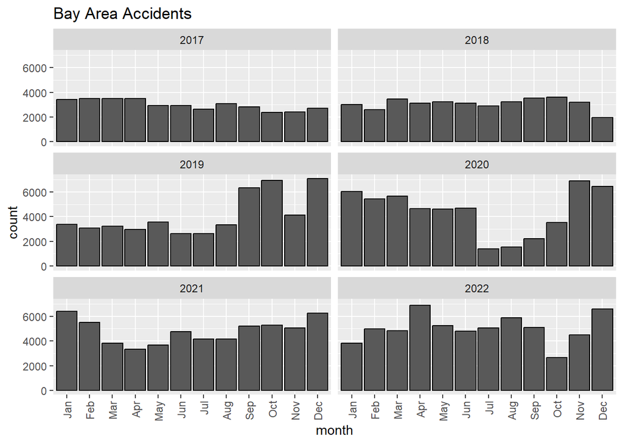

```r
ggplot(accidents_bay_area, aes(x = month)) +
  geom_bar(col = "black") +
  facet_wrap(~year, ncol = 2) +
  guides(x = guide_axis(angle = 90)) +
  ggtitle("Bay Area Accidents")
```

```r
ggsave("accident_facet_year.png", plot = last_plot())
```

## 2.) Barplot of accidents per month (2020)

```r
accidents_bay_area_2020 <- accidents_bay_area %>%
  filter(year == 2020)
```

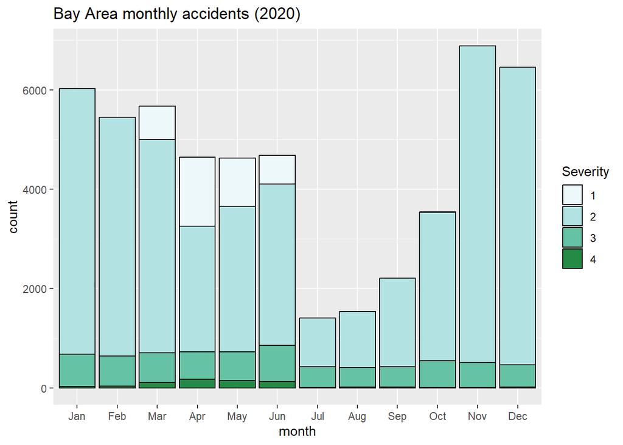

```r
accidents_bay_area_2020 %>%
  ggplot(aes(x = month)) +
  scale_fill_brewer(palette = "BuGn") +
  geom_bar(position = "stack", aes(fill = Severity), col = "black") +
  ggtitle("Bay Area monthly accidents (2020)")
```

```r
ggsave("accident_barplot_per_month_2020_bayarea_stack.png", plot = last_plot())
```

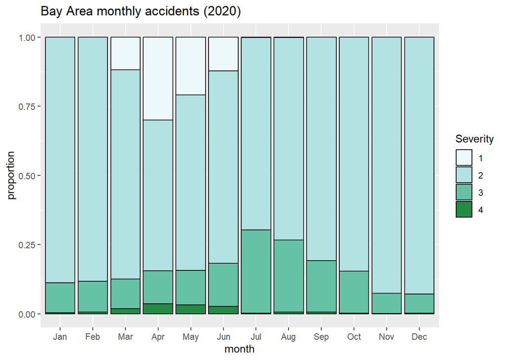

```r
accidents_bay_area_2020 %>%
  ggplot(aes(x = month)) +
  scale_fill_brewer(palette = "BuGn") +
  geom_bar(position = "fill", aes(fill = Severity), col = "black") +
  ylab("proportion") +
ggtitle("Bay Area monthly accidents (2020)")
```

```r
ggsave("accident_barplot_per_month_2020_bayarea_fill.png", plot = last_plot())
```

## 3.) Histogram of accidents per hour bay area

[figure not shown]

```r
ggplot(accidents_bay_area, aes(x = hour)) +
  scale_fill_brewer(palette = "Blues") +
  geom_histogram(aes(group = Severity, fill = Severity),
                 col = "black", bins = 24) +
  ggtitle("Bay Area hourly accidents (2020)")
```

```r
ggsave("accident_histogram_per_hour.png", plot = last_plot())
```

## 4. ) Map location of accidents in the bay area from July to October

```r
accidents_bay_area_2020_Jul_Oct <- accidents_bay_area_2020 %>%
  filter(month %in% c("Jul", "Aug", "Sep", "Oct"))
```

```r
head(accidents_bay_area_2020_Jul_Oct)
```

```
  Severity          Start_Time State       County Start_Lat Start_Lng
1        3 2020-10-31 21:20:00    CA Contra Costa        38      -122
2        2 2020-10-31 21:47:35    CA Contra Costa        38      -122
3        3 2020-10-31 22:24:09    CA      Alameda        38      -122
4        2 2020-10-31 20:10:42    CA       Sonoma        38      -123
5        2 2020-10-31 20:00:33    CA       Sonoma        39      -123
6        2 2020-10-31 00:02:14    CA    San Mateo        37      -122
  Weather_Condition Amenity  Bump Crossing Give_Way Junction No_Exit Railway
1             Smoke   FALSE FALSE    FALSE    FALSE    FALSE   FALSE   FALSE
2             Smoke   FALSE FALSE     TRUE    FALSE    FALSE   FALSE   FALSE
3              Fair   FALSE FALSE    FALSE    FALSE    FALSE   FALSE   FALSE
4              Fair   FALSE FALSE    FALSE    FALSE    FALSE   FALSE   FALSE
5              Fair   FALSE FALSE    FALSE    FALSE    FALSE   FALSE   FALSE
6              Fair   FALSE FALSE    FALSE    FALSE    FALSE   FALSE   FALSE
  Roundabout Station  Stop Traffic_Calming Traffic_Signal Turning_Loop year
1      FALSE   FALSE FALSE           FALSE          FALSE        FALSE 2020
2      FALSE   FALSE FALSE           FALSE          FALSE        FALSE 2020
3      FALSE   FALSE FALSE           FALSE          FALSE        FALSE 2020
4      FALSE   FALSE FALSE           FALSE          FALSE        FALSE 2020
5      FALSE   FALSE FALSE           FALSE          FALSE        FALSE 2020
6      FALSE   FALSE FALSE           FALSE          FALSE        FALSE 2020
        date month wday hour
1 2020-10-31   Oct  Sat   21
2 2020-10-31   Oct  Sat   21
3 2020-10-31   Oct  Sat   22
4 2020-10-31   Oct  Sat   20
5 2020-10-31   Oct  Sat   20
6 2020-10-31   Oct  Sat    0
```

```r
bay_area_lowercase <- tolower(bay_area)
```

```r
bay_area_map <- map_data("county", "california") %>%
  filter(subregion %in% bay_area_lowercase)
```

```r
head(bay_area_map)
```

```
  long lat group order     region subregion
1 -121  37     1     1 california   alameda
2 -122  37     1     2 california   alameda
3 -122  37     1     3 california   alameda
4 -122  37     1     4 california   alameda
5 -122  37     1     5 california   alameda
6 -122  37     1     6 california   alameda
```

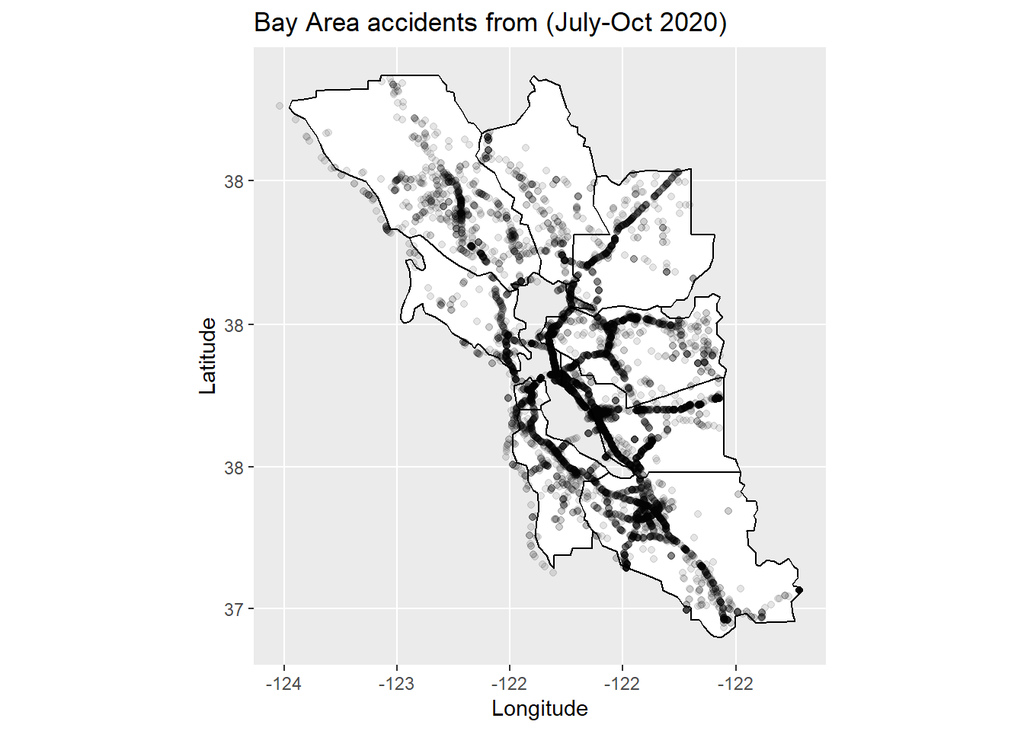

```r
ggplot() +
  geom_polygon(data = bay_area_map, aes(x=long, y = lat, group = group),
               fill = "white", color = "black") +
  geom_point(data = accidents_bay_area_2020_Jul_Oct,
             aes(x=Start_Lng, y = Start_Lat), alpha = 0.1) +
  coord_map() +
  ylab("Latitude") +
  xlab("Longitude") +
  ggtitle("Bay Area accidents from (July-Oct 2020)")
```

```r
ggsave("accident_map_2020_Jul_Oct.png", plot = last_plot())
```

## Severity >= 3 primarily happens on freeways in the SF Bay Area

```r
accidents_bay_area_severity_3plus <- accidents_bay_area %>%
  filter(Severity >=3, year >= 2020)
```

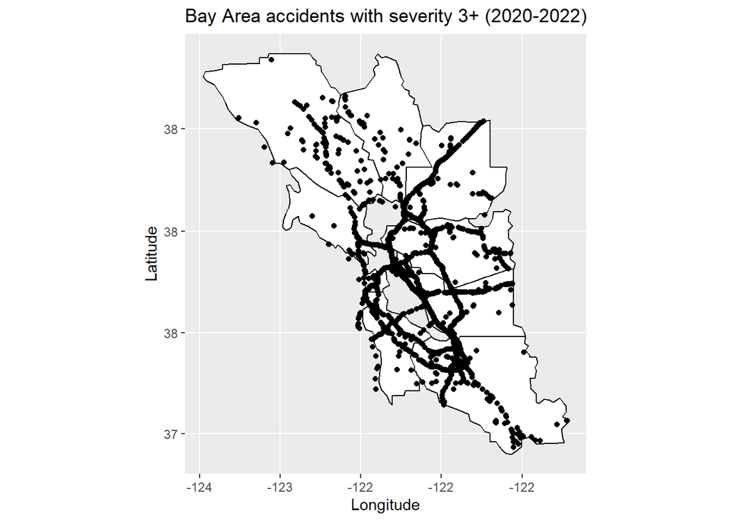

```r
ggplot() +
  geom_polygon(data = bay_area_map, aes(x=long, y = lat, group = group),
               fill = "white", color = "black") +
  geom_point(data = accidents_bay_area_severity_3plus,
             aes(x=Start_Lng, y = Start_Lat), alpha = 1) +
  coord_map() +
  ylab("Latitude") +
  xlab("Longitude") +
  ggtitle("Bay Area accidents with severity 3+ (2020-2022)")
```

```r
ggsave("accident_map_bayarea_severity3plus.png", plot = last_plot())
```

## leaflet since to show the roads that is not on the ggplot above

```r
library(leaflet)
```

```r
leaflet(data = accidents_bay_area_severity_3plus) %>%
  addTiles() %>%
  addCircleMarkers(
    lng = ~Start_Lng,
    lat = ~Start_Lat,
    popup = ~paste(Start_Time, "<br>", "Severity =", Severity),
    radius = 1
  )
```

[interactive chart not shown]

# 6.) nearby POIs where accidents happen

```r
accident_count <- nrow(accidents_bay_area)
accident_count
```

```
[1] 292813
```

```r
POI_accidents <- accidents_bay_area %>%
  select(Amenity:Turning_Loop, Severity) %>%
  pivot_longer(Amenity:Turning_Loop, names_to = "POI") %>%
  select(POI, value, Severity) %>%
  mutate(POI = as.factor(POI))
```

```r
head(POI_accidents)
```

```
# A tibble: 6 × 3
  POI      value Severity
  <fct>    <lgl> <chr>
1 Amenity  FALSE 3
2 Bump     FALSE 3
3 Crossing FALSE 3
4 Give_Way FALSE 3
5 Junction FALSE 3
6 No_Exit  FALSE 3
```

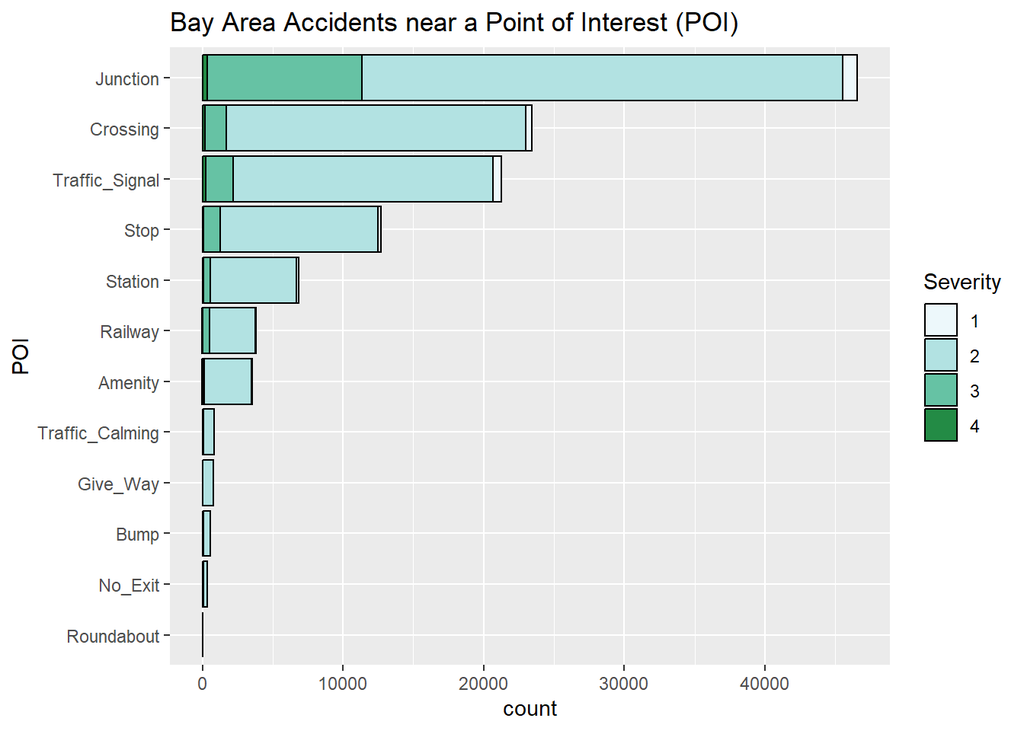

```r
POI_accidents %>%
  filter(value == TRUE) %>%
  ggplot(aes(y = fct_rev(fct_infreq(POI)))) +
  scale_fill_brewer(palette = "BuGn") +
  geom_bar(aes(fill = Severity), position = "stack", col = "black") +
  ylab("POI") +
  ggtitle("Bay Area Accidents near a Point of Interest (POI)")
```

```r
ggsave("accidents_stackbar_POI.png", plot = last_plot())
```

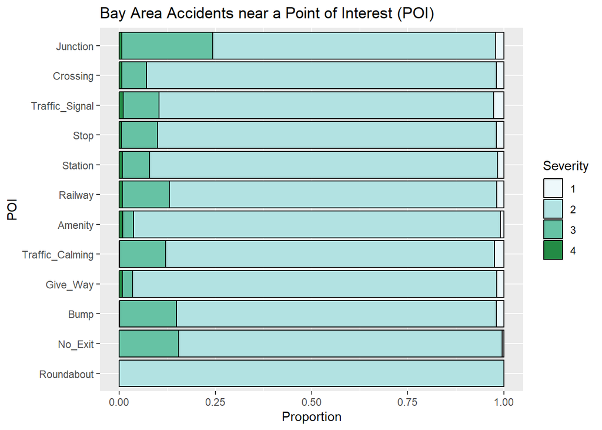

```r
POI_accidents %>%
  filter(value == TRUE) %>%
  ggplot(aes(y = fct_rev(fct_infreq(POI)))) +
  scale_fill_brewer(palette = "BuGn") +
  geom_bar(aes(fill = Severity), position = "fill", col = "black") +
  ylab("POI") +
  xlab("Proportion") +
  ggtitle("Bay Area Accidents near a Point of Interest (POI)")
```

```r
ggsave("accidents_fillbar_POI.png", plot = last_plot())
```

# 7.) Weather conditions when accidents happen

```r
Weather_accidents <- accidents_bay_area %>%
  filter(Weather_Condition != "") %>%
  select(Weather_Condition, Severity)
```

```r
head(Weather_accidents)
```

```
  Weather_Condition Severity
1     Partly Cloudy        3
2          Overcast        3
3     Partly Cloudy        2
4     Mostly Cloudy        3
5     Mostly Cloudy        3
6          Overcast        2
```

```r
top_weather_conditions <- Weather_accidents %>%
  group_by(Weather_Condition) %>%
  summarize(count = n()) %>%
  arrange(desc(count)) %>%
  head(10) %>%
  select(Weather_Condition)
```

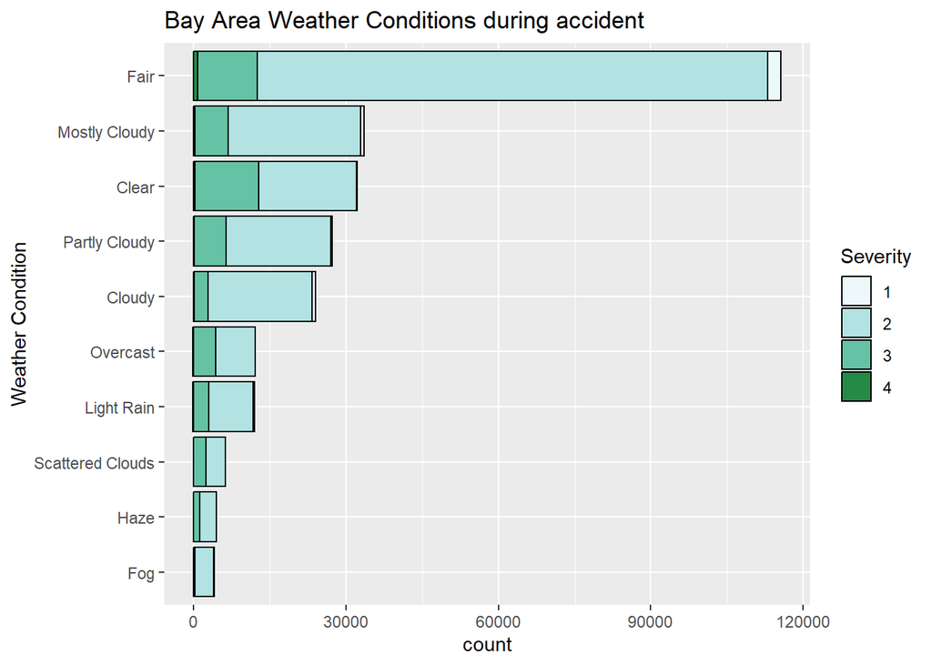

```r
Weather_accidents%>%
  filter(Weather_Condition %in% top_weather_conditions$Weather_Condition) %>%
  ggplot(aes(y = fct_rev(fct_infreq(Weather_Condition)))) +
  scale_fill_brewer(palette = "BuGn") +
  geom_bar(aes(fill = Severity), position = "stack", col = "black") +
  ylab("Weather Condition") +
  ggtitle("Bay Area Weather Conditions during accident")
```

```r
ggsave("accidents_stackbar_Weather.png", plot = last_plot())
```

# Data set Link

https://www.kaggle.com/datasets/sobhanmoosavi/us-accidents?resource=download

# Citations as requested by the dataset

- Moosavi, Sobhan, Mohammad Hossein Samavatian, Srinivasan Parthasarathy, and Rajiv Ramnath. “[A Countrywide Traffic Accident Dataset](https://arxiv.org/abs/1906.05409).”, 2019.
- Moosavi, Sobhan, Mohammad Hossein Samavatian, Srinivasan Parthasarathy, Radu Teodorescu, and Rajiv Ramnath. [“Accident Risk Prediction based on Heterogeneous Sparse Data: New Dataset and Insights.”](https://arxiv.org/abs/1909.09638) In proceedings of the 27th ACM SIGSPATIAL International Conference on Advances in Geographic Information Systems, ACM, 2019.